# Unit 1 Project - Alcohol Use Disorder in Adolescents

Author

Felix G., Sev T., Alayna C., Emry L.

## Overview

For our project, we decided to look at a topic based in social sciences due to a connection to our majors and interest areas. We focused on drug abuse and found a data set concerning the substance abuse disorders in the 50 states and District of Columbia. We decided to look at alcohol use disorder primarily, with a secondary analysis comparing alcohol and marijuana use.

## Data Wrangling

```r
# Load resources
library(tidyverse)

d <- read.csv("../data/drugs.csv")
```

We found a data source through corgis.edu, a site Felix had worked with in the past. This source had more than enough observations, so we did not have to combine multiple sources and only had to download it as a CSV file and load it into RStudio.

From there, we filtered the dataset to keep only years 2018, 2013, and 2008. We also dropped most of the columns, keeping only “State,” “Year,” “Rates.Alcohol.Use.Disorder.Past.Year.12.17”, “Rates.Alcohol.Use.Disorder.Past.Year.18.25”, and “Rates.Marijuana.Used.Past.Year.12.17. The last three columns were renamed to”Rates_12_17”, “Rates_18_25”, and “Mari_12_17” respectively.

“State” is character data that includes all 50 states plus the District of Columbia.

“Year” is integer data that spanned from 2002 to 2018, though we filtered down to only leave 2018, 2013, and 2008.

```r
# Create vectors by isolating data that fits our criteria for Population A (12-17)
PopA <- d |>
  filter(Year == "2018" | Year == "2013" | Year == "2008") |>
  select(c(
    State,
    Year,
    Rates.Alcohol.Use.Disorder.Past.Year.12.17,
    Rates.Alcohol.Use.Disorder.Past.Year.18.25,
    Rates.Marijuana.Used.Past.Year.12.17
    )
  ) # Select the columns of interest

# Felix 3-5-25

# AUD (Alcohol Use Disorder) [for ages 12-17]
# Added Mari_12_17 - rates of marijuana use in past year for same age group
AUD <- tibble( # Create tibble AUD, set variables
  State = PopA$State,
  Year = PopA$Year,
  Rates_12_17 = PopA$Rates.Alcohol.Use.Disorder.Past.Year.12.17,
  Rates_18_25 = PopA$Rates.Alcohol.Use.Disorder.Past.Year.18.25,
  Mari_12_17 = PopA$Rates.Marijuana.Used.Past.Year.12.17
)

AUD
```

```
# A tibble: 153 × 5
   State                 Year Rates_12_17 Rates_18_25 Mari_12_17
   <chr>                <int>       <dbl>       <dbl>      <dbl>
 1 Alabama               2008        41.2        137.       101.
 2 Alaska                2008        53.1        169.       159.
 3 Arizona               2008        54.0        182.       143.
 4 Arkansas              2008        49.0        156.       123.
 5 California            2008        52.7        164.       151.
 6 Colorado              2008        63.2        210.       185.
 7 Connecticut           2008        59.2        199.       159.
 8 Delaware              2008        48.6        190.       155.
 9 District of Columbia  2008        30.4        170.       146.
10 Florida               2008        43.3        146.       129.
# ℹ 143 more rows
```

```r
# Felix 3-5-25
```

## Visualization

### Fig. A) Comparing alcohol use between all 50 states

Alayna - My part in the Unit 1 Group Project’s visualizations was to create a histogram. The coding I used was imported using the read.csv () command and was made to include the years 2008, 2013, and 2018. The column titled “Rates.Alcohol.Use.Disorder.Past.Year.18.25” was changed to “Rates” for clarity. The x-axis symbolized the rates variable that acted for the percentage of 18-25 years olds with alcohol use disorder, while the y-axis represented the state variable that was reorganized based on the Rates. The fill aesthetic was based on the year variable, making the different years different shades of green (pale green, lime green, and forest green). The geom_histogram(stat = “identity”) command displayed the alcohol use disorder rates as bars. Position = “dodge” ensured that the bars for the years (2008, 2013, 2018) were placed next to each other for comparison. The width = 0.7 command was used to help with the bars’ visibility.

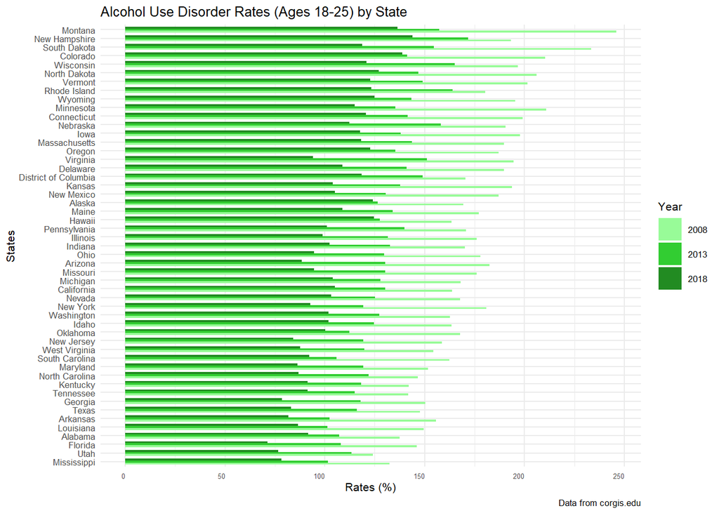

```r
df <- read.csv("../data/drugs.csv")

df_filtered <- df %>%
  filter (Year %in% c(2008, 2013, 2018)) %>%
  select(State, Year, Rates = 'Rates.Alcohol.Use.Disorder.Past.Year.18.25')

ggplot(df_filtered, aes(
  x = Rates,
  y = reorder(State, Rates),
  fill = factor (Year))) +
  geom_histogram(stat = "identity", position = "dodge", width = 0.7) +
  labs(title = "Alcohol Use Disorder Rates (Ages 18-25) by State",
       y = "States",
       x = "Rates (%)",
       fill = "Year",
       caption = "Data from corgis.edu") +
  scale_fill_manual(
    values = c(
      "2008" = "palegreen",
      "2013" = "limegreen",
      "2018" = "forestgreen")
    ) +
  theme_minimal (base_size = 8) +
  theme(axis.text.x = element_text(
    angle = 360,
    hjust = 1,
    vjust = 0.5,
    size = 4.7)
  )
```

### Fig. B) Comparing national alcohol use rates over time

Emry - I was tasked with creating a temporal visualization showcasing the three years we chose. To do this, I mapped Year to the x-axis and rates to the y-axis. I knew that I wanted to use a jitter plot since there were only three values along the x axis, though I did not know how to represent both age groups. I spoke with Dr. Girard and he introduced the pivot_longer command. I also added a geom_smooth line to show the trend of the datapoints for each age group. Beyond this, the rest of the code was added for aesthetic purposes, such as sizing and cleaning up the scale.

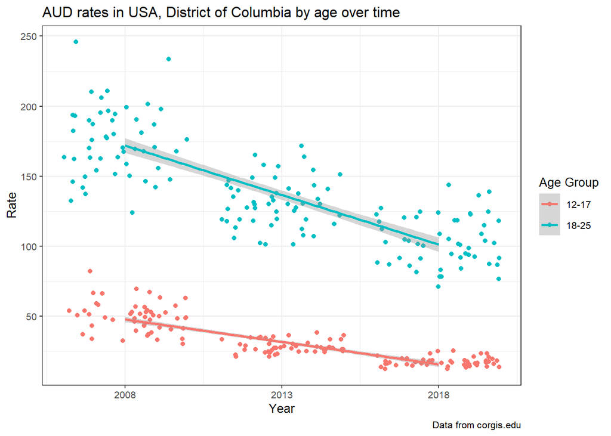

```r
#Create tibble, join rates columns into column Age_Group with new column rates
AUD2 <-
  AUD |>
  pivot_longer(
    Rates_12_17:Rates_18_25,
    names_to = "Age_Group",
    values_to = "Rate"
  )

#Create+format figure showing rate by year with both age groups colored coded

ggplot(AUD2, aes(x = Year, y = Rate, color = Age_Group)) + geom_jitter() +
  scale_color_discrete(
    labels = c("Rates_12_17" = "12-17", "Rates_18_25" = "18-25")) +
  labs(title = "AUD rates in USA, District of Columbia by age over time") +
  scale_x_continuous(breaks = c(2008, 2013, 2018)) +
  theme_bw(base_size = 10) +
  geom_smooth(method = "lm") +
  labs(color = "Age Group") +
  labs(caption = "Data from corgis.edu")
```

```r
# Scale shows three years we are focusing on
# Sizing changed so title is not cut off
# Linear regression added to demonstrate trend
# Emry 3.11.25
```

### Fig. C) Comparing alcohol use between age groups and states: KS and MO

Sev - The process of deciding on my figure was a trial and error one. I first played around with the box plot but decided that it was not as clear. Then I transitioned into a violin plot, but it was still confusing to look at visually. Then I came to the final conclusion of using the density plot because it was really easy to see visually. One of the things that I struggled with was putting all of the data onto the density plot. The way I combatted this was making one of the data points “Ages 18-25” a dashed line so it was easier to distinguish between them. Asked Dr. Girard on how to make it look visually better and he used pivot_longer and helped us with the code.

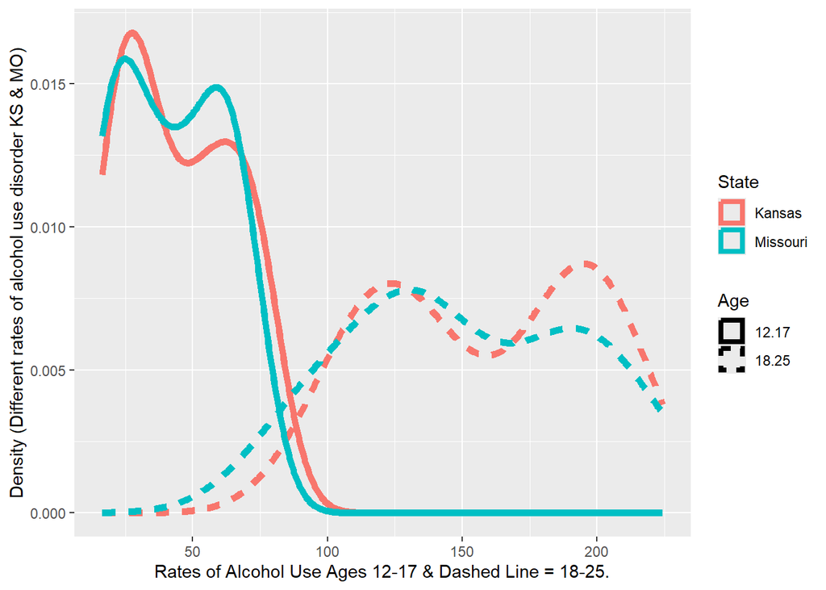

```r
## Filters the dataset for Kansas and Missouri
PopB <- d |>
  filter(State == "Kansas" | State == "Missouri") |>
  select(
    State,
    Year,
    Rates.Alcohol.Use.Disorder.Past.Year.12.17,
    Rates.Alcohol.Use.Disorder.Past.Year.18.25) |>
  pivot_longer(
    cols = c(
      Rates.Alcohol.Use.Disorder.Past.Year.18.25,
      Rates.Alcohol.Use.Disorder.Past.Year.12.17),
    names_to = "Age",
    values_to = "Rate",
    names_prefix = "Rates.Alcohol.Use.Disorder.Past.Year."
  )

ggplot(PopB) +
  # Plots ages 12-17
  geom_density(aes(x = Rate, color = State, linetype = Age), linewidth = 2) +
  labs(
    x = "Rates of Alcohol Use Ages 12-17 & Dashed Line = 18-25.",
    y = "Density (Different rates of alcohol use disorder KS & MO)",
    fill = "State",
    color = "State"
  )
```

```r
# Sev 3.12.25
```

### Fig D) Comparing Alcohol Use and Marijuana Use

Felix - For this graph I wanted to see if there was a correlation between alcohol use and marijuana use in the past year for the 12-17 age group. I tried a couple of different plots, but a simple scatterplot was the best approach to look at two continuous variables. I added a smooth so that it would show the mean trend line. To differentiate the years that we isolated (2008, 2013, 2018), I set both color and shape to be mapped to the year.

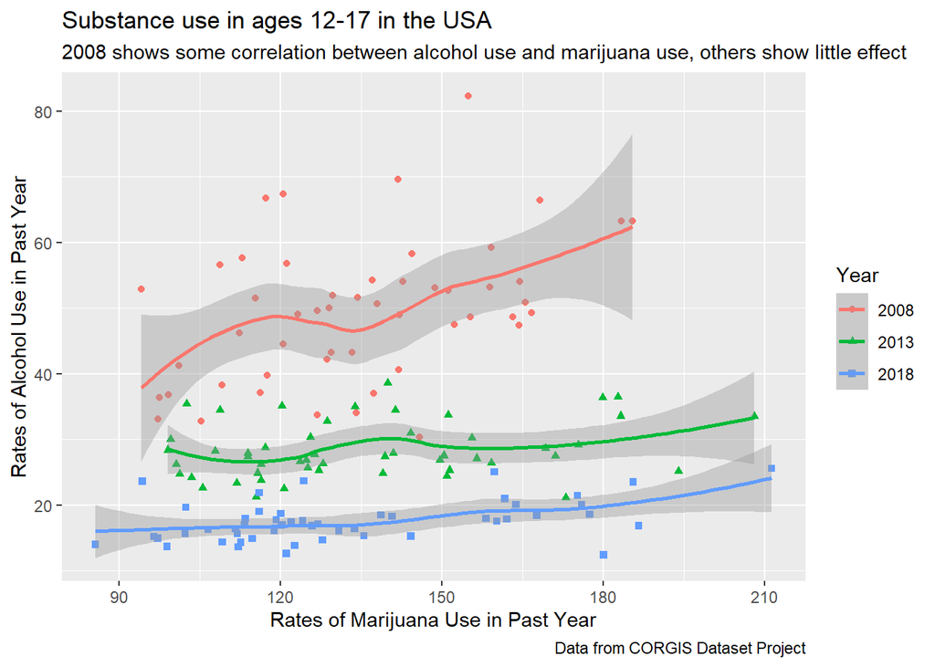

```r
# Creates a scatterplot comparing rates of alcohol use and marijuana use in the past year for ages 12-17

ggplot(AUD,
  aes(
    y = Rates_12_17,
    x = Mari_12_17,
    color = factor(Year),
    shape = factor(Year)
    )
  ) +
  geom_point() +
  geom_smooth() +
  labs(
    title = "Substance use in ages 12-17 in the USA",
    subtitle = "2008 shows some correlation between alcohol use and marijuana use, others show little effect",
    caption = "Data from CORGIS Dataset Project",

    x = "Rates of Marijuana Use in Past Year",
    y = "Rates of Alcohol Use in Past Year",

    color = "Year",
    shape = "Year"
  )
```

```r
# Felix 3-12-25
```

## Conclusions

Based on our graphs, we can see that alcohol use in the 12-17 age category across the country was on the decline during the 10-year period that we observed. We can also see that both Kansas and Missouri show similar trends in alcohol use between the 12-17 and 18-25 age groups. This trend is supported on the national level, where we see a higher density of high-rate alcohol use in the 18-25 age category than the 12-17, which makes sense due to national liquor laws. As for correlating alcohol use with another drug, like marijuana, we did not see a significant connection between the two.

*For conclusions based on individual figures, see the following:*

### Fig. B - *Emry*

The age range of 18-25 has higher overall rates of Alcohol Use Disorder rates. However, though both age groups see a downturn in rates across time, 18-25 sees a steeper negative regression slope.

### Fig. C - *Sev*

This graph shows that for people ages 12-17, the consumption of alcohol was greater in Kansas for the majority of the time. For people ages 18-25, the consumption of alcohol was greater in Kansas as well with a big change at around 180 rates.

### Fig. D - *Felix*

This graph shows that there are no major correlations between alcohol use and marijuana use for the 12-17 age group for the years that we selected. 2008 shows a greater slope, suggesting a correlation, but the points vary significantly, so this could be due to outlier influence. Overall, we can see that rates of alcohol use throughout the US decreased over 10 years, with marijuana use remaining relatively steady, with some states reporting greater use, and some with less.